# COVID and GDP

casey durfee

1/18/2022

## Description

I decided to look at how COVID fatalities correlate with income in the United States.

I obtained county-level COVID data from Johns Hopkins University and the county-level per capita income data from Wikipedia.

For COVID, I am using the total death counts as of 12/31/2021.

The income data is from the 2009–2013 American Community Survey 5-Year Estimates.

```r
covid_url <- "https://raw.githubusercontent.com/CSSEGISandData/COVID-19/master/csse_covid_19_data/csse_covid_19_time_series/time_series_covid19_deaths_US.csv"

deaths_by_county <- read_csv(covid_url, show_col_types = FALSE) %>%
      mutate(CountyState = paste(Admin2, Province_State, sep = ', ')) %>%
      rename("Deaths" = "12/31/21") %>%
      select(CountyState, Deaths)

gdp_table <- read_html("https://en.wikipedia.org/wiki/List_of_United_States_counties_by_per_capita_income") %>%
        html_element(xpath = "//table[3]") %>%
        html_table()

colnames(gdp_table) <- c("Rank", "County", "State",
        "PerCapitaIncome", "MedianHousehold", "MedianFamily", "Population", "NumHouseholds")

gdp_table <- gdp_table %>%
              filter(Rank != "—") %>%
              mutate(CountyState = paste(str_trim(County), State, sep = ', '),
                    PerCapitaIncome = parse_number(PerCapitaIncome),
                    MedianHousehold = parse_number(MedianHousehold),
                    MedianFamily = parse_number(MedianFamily),
                    Population = parse_number(Population),
                    NumHouseholds = parse_number(NumHouseholds),
                    Rank = parse_number(Rank)
              )
```

We’ll merge the two data samples together, and calculate the per-capita fatality rate for COVID using the population counts from Wikipedia.

```r
merged <- left_join(deaths_by_county, gdp_table, by = c("CountyState" = "CountyState")) %>%
        mutate(PerCapitaDeaths = Deaths / Population) %>%
        filter(!is.na(PerCapitaIncome))

cor(merged$PerCapitaDeaths, merged$PerCapitaIncome)
```

```
## [1] -0.411392
```

```r
cor(merged$PerCapitaDeaths, merged$MedianHousehold)
```

```
## [1] -0.4243724
```

```r
cor(merged$PerCapitaDeaths, merged$MedianFamily)
```

```
## [1] -0.4395804
```

All of the income measures are correlated with per-capita deaths, with median family income being the strongest predictor.

```r
l <- lm(merged$PerCapitaDeaths ~ merged$MedianFamily)

summary(l)
```

```
##
## Call:
## lm(formula = merged$PerCapitaDeaths ~ merged$MedianFamily)
##
## Residuals:
##        Min         1Q     Median         3Q        Max
## -0.0040277 -0.0008102 -0.0000611  0.0007099  0.0099855
##
## Coefficients:
##                       Estimate Std. Error t value Pr(>|t|)
## (Intercept)          5.561e-03  9.769e-05   56.92   <2e-16 ***
## merged$MedianFamily -4.522e-08  1.682e-09  -26.88   <2e-16 ***
## ---
## Signif. codes:  0 '***' 0.001 '**' 0.01 '*' 0.05 '.' 0.1 ' ' 1
##
## Residual standard error: 0.001246 on 3017 degrees of freedom
## Multiple R-squared:  0.1932, Adjusted R-squared:  0.193
## F-statistic: 722.6 on 1 and 3017 DF,  p-value: < 2.2e-16
```

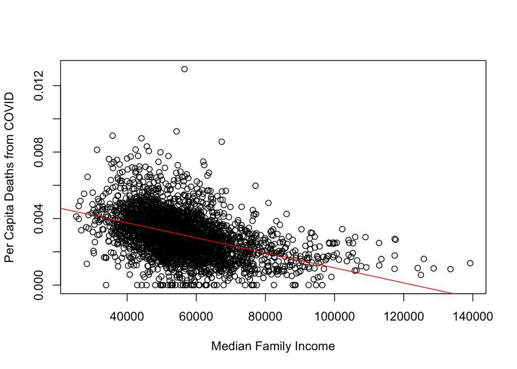

```
## integer(0)
```

```r
plot(merged$MedianFamily, merged$PerCapitaDeaths,
     xlab="Median Family Income",
     ylab="Per Capita Deaths from COVID") + abline(l, col='red')
```

## Missing Data

There are many data points reporting zero COVID deaths. It turns out some of those counties are fairly large:

```r
zero_deaths <- merged %>% filter(PerCapitaDeaths == 0)

zd <- zero_deaths[order(zero_deaths$Population, decreasing = TRUE), ]

head(zd)
```

| CountyState | Deaths | Rank | County | State | PerCapitaIncome | MedianHousehold | MedianFamily | Population | NumHouseholds | PerCapitaDeaths |
| --- | --- | --- | --- | --- | --- | --- | --- | --- | --- | --- |
| Weber, Utah | 0 | 1523 | Weber | Utah | 23106 | 54974 | 62642 | 233871 | 79525 | 0 |
| Cache, Utah | 0 | 2319 | Cache | Utah | 20074 | 49506 | 57220 | 114181 | 35375 | 0 |
| Box Elder, Utah | 0 | 1895 | Box Elder | Utah | 21720 | 57292 | 62898 | 50160 | 16207 | 0 |
| Iron, Utah | 0 | 2814 | Iron | Utah | 17839 | 42369 | 49829 | 46435 | 15435 | 0 |
| Uintah, Utah | 0 | 1328 | Uintah | Utah | 23805 | 62067 | 65922 | 33722 | 11007 | 0 |
| Sanpete, Utah | 0 | 2816 | Sanpete | Utah | 17811 | 48369 | 58486 | 27930 | 7781 | 0 |

It’s highly unlikely that Weber County, with a population of 233,871, has had zero COVID fatalities. Currently about 3/1000 Americans have died of COVID, so we would expect about 700 COVID deaths in Weber County.

In total, there are about 700,000 people living in counties with zero reported fatalities in the Johns Hopkins data. Utah is the worst offender.

```r
sum(zd$Population)
```

```
## [1] 714870
```

```r
by_state <- zd %>% group_by(State) %>% summarize(total = sum(Population))

by_state[order(by_state$total, decreasing = TRUE), ]
```

| State | total |
| --- | --- |
| Utah | 646620 |
| Massachusetts | 26963 |
| Washington | 15786 |
| Nebraska | 10153 |
| California | 4292 |
| Colorado | 2839 |
| Oklahoma | 2432 |
| Alaska | 2013 |
| Nevada | 1804 |
| Idaho | 751 |

[output cut: 3 more lines]

So, it’s worth redoing the fit without the 0 fatality counties, even though there probably are some small counties that actually don’t have any fatalities.

```r
without_zero_deaths <- merged %>%
                filter(PerCapitaDeaths != 0)

l <- lm(without_zero_deaths$PerCapitaDeaths ~ without_zero_deaths$MedianFamily)

summary(l)
```

```
##
## Call:
## lm(formula = without_zero_deaths$PerCapitaDeaths ~ without_zero_deaths$MedianFamily)
##
## Residuals:
##        Min         1Q     Median         3Q        Max
## -0.0031152 -0.0008247 -0.0000857  0.0006764  0.0099424
##
## Coefficients:
##                                    Estimate Std. Error t value Pr(>|t|)
## (Intercept)                       5.564e-03  9.533e-05   58.36   <2e-16 ***
## without_zero_deaths$MedianFamily -4.451e-08  1.645e-09  -27.07   <2e-16 ***
## ---
## Signif. codes:  0 '***' 0.001 '**' 0.01 '*' 0.05 '.' 0.1 ' ' 1
##
## Residual standard error: 0.001205 on 2970 degrees of freedom
## Multiple R-squared:  0.1979, Adjusted R-squared:  0.1976
## F-statistic: 732.6 on 1 and 2970 DF,  p-value: < 2.2e-16
```

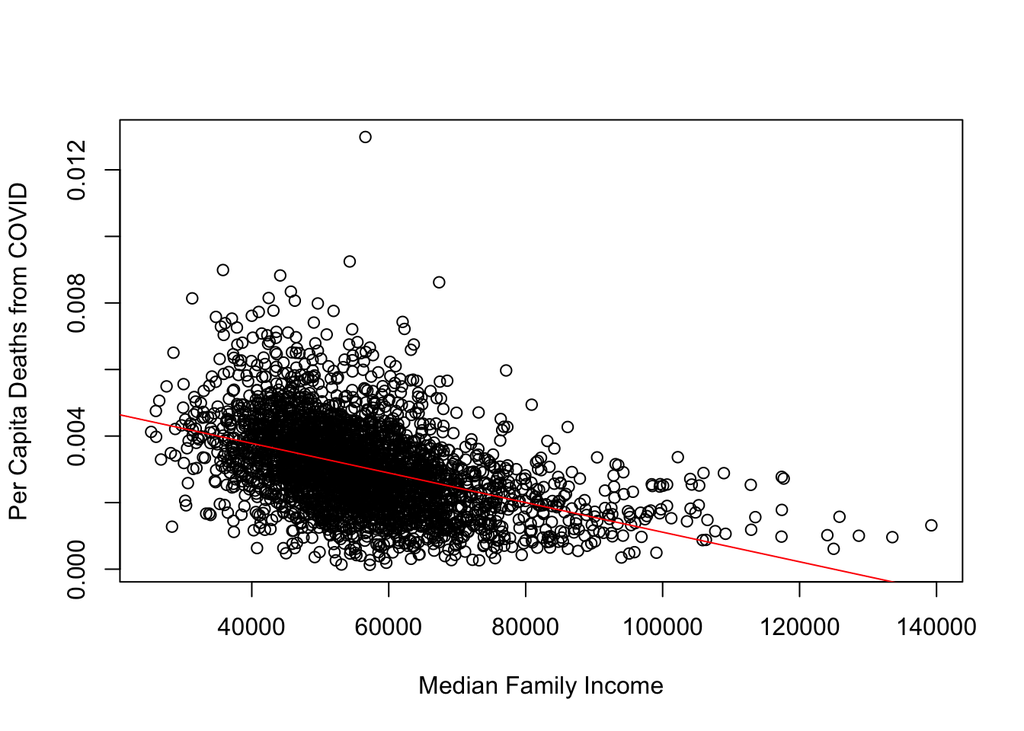

```
## integer(0)
```

```r
plot(without_zero_deaths$MedianFamily,
     without_zero_deaths$PerCapitaDeaths,
     xlab="Median Family Income",
     ylab="Per Capita Deaths from COVID") + abline(l, col='red')
```

The fit is only slightly better, with the R-squared value going from .19 to .20.

## Bias/Conclusion

There appears to be a correlation between income and COVID fatality rate, although the COVID data is incomplete from some counties, particularly in the state of Utah.

I don’t think I did anything biased in my analysis, but I did get the result I was expecting – that richer counties would have a lower COVID fatality rate than poorer counties.

There may also be other biases in the data – over or under-reporting of COVID deaths, for instance. Additionally, the per capita income data is based on estimates from 2013, which isn’t ideal.

I think the next step would be to compare counties within states, and compare states with similar states, in order to control for other factors and focus specifically on income.

In Colorado, for instance, do poorer counties have a higher COVID fatality rate than richer counties? And how well does the state-level GDP predict COVID fatality rate? That would probably give more insight to the link between GDP and COVID rather than comparing every county in the US with each other.